# Regression modelling in R

Rizny Mubarak

## 1. Lab Experiment

### Load dataset

```r
if (!("mlbench" %in% rownames(installed.packages()))){
  install.packages("mlbench")
}
library(mlbench)
```

```r
data(BostonHousing2)
x <- BostonHousing2
x <- x[,-5]
```

- Check first 5 rows of data

```r
head(x)
```

|  | town | tract | lon | lat | cmedv | crim | zn | indus | chas | nox | rm | age | dis | rad | tax | ptratio | b | lstat |
| --- | --- | --- | --- | --- | --- | --- | --- | --- | --- | --- | --- | --- | --- | --- | --- | --- | --- | --- |
| 1 | Nahant | 2011 | -70.9550 | 42.2550 | 24.0 | 0.00632 | 18 | 2.31 | 0 | 0.538 | 6.575 | 65.2 | 4.0900 | 1 | 296 | 15.3 | 396.90 | 4.98 |
| 2 | Swampscott | 2021 | -70.9500 | 42.2875 | 21.6 | 0.02731 | 0 | 7.07 | 0 | 0.469 | 6.421 | 78.9 | 4.9671 | 2 | 242 | 17.8 | 396.90 | 9.14 |
| 3 | Swampscott | 2022 | -70.9360 | 42.2830 | 34.7 | 0.02729 | 0 | 7.07 | 0 | 0.469 | 7.185 | 61.1 | 4.9671 | 2 | 242 | 17.8 | 392.83 | 4.03 |
| 4 | Marblehead | 2031 | -70.9280 | 42.2930 | 33.4 | 0.03237 | 0 | 2.18 | 0 | 0.458 | 6.998 | 45.8 | 6.0622 | 3 | 222 | 18.7 | 394.63 | 2.94 |
| 5 | Marblehead | 2032 | -70.9220 | 42.2980 | 36.2 | 0.06905 | 0 | 2.18 | 0 | 0.458 | 7.147 | 54.2 | 6.0622 | 3 | 222 | 18.7 | 396.90 | 5.33 |
| 6 | Marblehead | 2033 | -70.9165 | 42.3040 | 28.7 | 0.02985 | 0 | 2.18 | 0 | 0.458 | 6.430 | 58.7 | 6.0622 | 3 | 222 | 18.7 | 394.12 | 5.21 |

- Convert to Dataframe

```r
x <- as.data.frame(x)
```

- Check the class of all columns

```r
lapply(x,class)
```

```
## $town
## [1] "factor"
##
## $tract
## [1] "integer"
##
## $lon
## [1] "numeric"
##
## $lat
## [1] "numeric"
##
## $cmedv
## [1] "numeric"
##
## $crim
## [1] "numeric"
##
## $zn
## [1] "numeric"
##
## $indus
## [1] "numeric"
##
## $chas
## [1] "factor"
##
## $nox
## [1] "numeric"
##
## $rm
## [1] "numeric"
##
## $age
## [1] "numeric"
##
## $dis
## [1] "numeric"
##
## $rad
## [1] "integer"
##
## $tax
## [1] "integer"
##
## $ptratio
## [1] "numeric"
##
## $b
## [1] "numeric"
##
## $lstat
## [1] "numeric"
```

- Get all the numeric columns indexs

```r
idxNum <- unlist(lapply(x,class)) == "numeric"
```

### Data exploration

- Find Correlations

```r
cor(x[,idxNum])
```

```
##                 lon          lat        cmedv        crim         zn
## lon      1.00000000  0.143053589 -0.322946685  0.06510061 -0.2180811
## lat      0.14305359  1.000000000  0.006825792 -0.08429296 -0.1296674
## cmedv   -0.32294669  0.006825792  1.000000000 -0.38958244  0.3603862
## crim     0.06510061 -0.084292955 -0.389582441  1.00000000 -0.2004692
## zn      -0.21808107 -0.129667394  0.360386177 -0.20046922  1.0000000
## indus    0.06270245 -0.041093480 -0.484754379  0.40658341 -0.5338282
## nox      0.16087125 -0.068600401 -0.429300219  0.42097171 -0.5166037
## rm      -0.25711003 -0.069316987  0.696303794 -0.21924670  0.3119906
## age      0.20473895  0.079035217 -0.377998896  0.35273425 -0.5695373
## dis     -0.01124313 -0.082980855  0.249314834 -0.37967009  0.6644082
## ptratio  0.31260219 -0.004527081 -0.505654619  0.28994558 -0.3916785
## b       -0.01829986  0.105253702  0.334860832 -0.38506394  0.1755203
## lstat    0.19562959  0.045659550 -0.740835993  0.45562148 -0.4129946
##               indus        nox          rm         age         dis      ptratio
## lon      0.06270245  0.1608713 -0.25711003  0.20473895 -0.01124313  0.312602186
## lat     -0.04109348 -0.0686004 -0.06931699  0.07903522 -0.08298085 -0.004527081
## cmedv   -0.48475438 -0.4293002  0.69630379 -0.37799890  0.24931483 -0.505654619
## crim     0.40658341  0.4209717 -0.21924670  0.35273425 -0.37967009  0.289945579
## zn      -0.53382819 -0.5166037  0.31199059 -0.56953734  0.66440822 -0.391678548
## indus    1.00000000  0.7636514 -0.39167585  0.64477851 -0.70802699  0.383247556
## nox      0.76365145  1.0000000 -0.30218819  0.73147010 -0.76923011  0.188932677
## rm      -0.39167585 -0.3021882  1.00000000 -0.24026493  0.20524621 -0.355501495
## age      0.64477851  0.7314701 -0.24026493  1.00000000 -0.74788054  0.261515012
## dis     -0.70802699 -0.7692301  0.20524621 -0.74788054  1.00000000 -0.232470542
## ptratio  0.38324756  0.1889327 -0.35550149  0.26151501 -0.23247054  1.000000000
## b       -0.35697654 -0.3800506  0.12806864 -0.27353398  0.29151167 -0.177383302
## lstat    0.60379972  0.5908789 -0.61380827  0.60233853 -0.49699583  0.374044317
##                   b       lstat
## lon     -0.01829986  0.19562959
## lat      0.10525370  0.04565955
## cmedv    0.33486083 -0.74083599
## crim    -0.38506394  0.45562148
## zn       0.17552032 -0.41299457
## indus   -0.35697654  0.60379972
## nox     -0.38005064  0.59087892
## rm       0.12806864 -0.61380827
## age     -0.27353398  0.60233853
## dis      0.29151167 -0.49699583
## ptratio -0.17738330  0.37404432
## b        1.00000000 -0.36608690
## lstat   -0.36608690  1.00000000
```

```r
a <- x[,3]
b <- x[,4]
cor(a,b)
```

```
## [1] 0.1430536
```

- Plot correlations

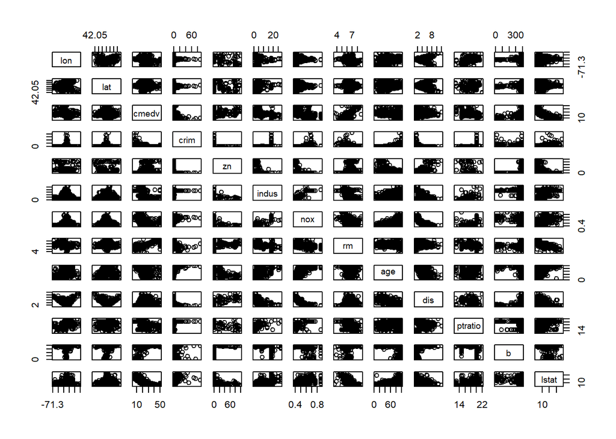

```r
plot(x[,idxNum])
```

- Scatter plot with two variables

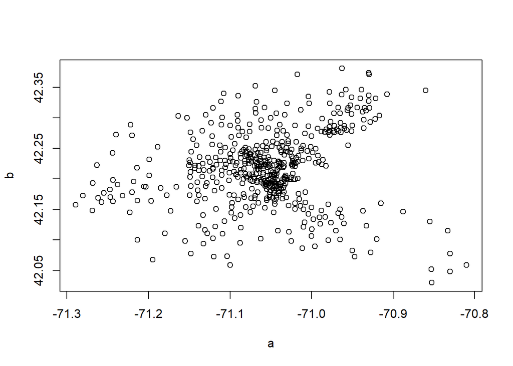

```r
plot(a,b)
```

- Scatter plot with colors

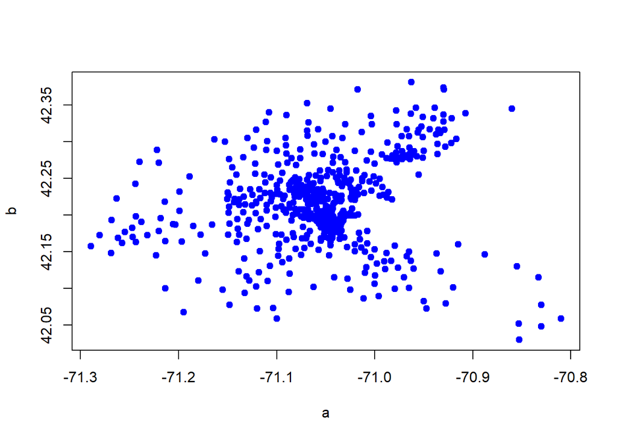

```r
plot(a,b,pch=19,col="blue")
```

- Plot scatter plot targets vs input variables

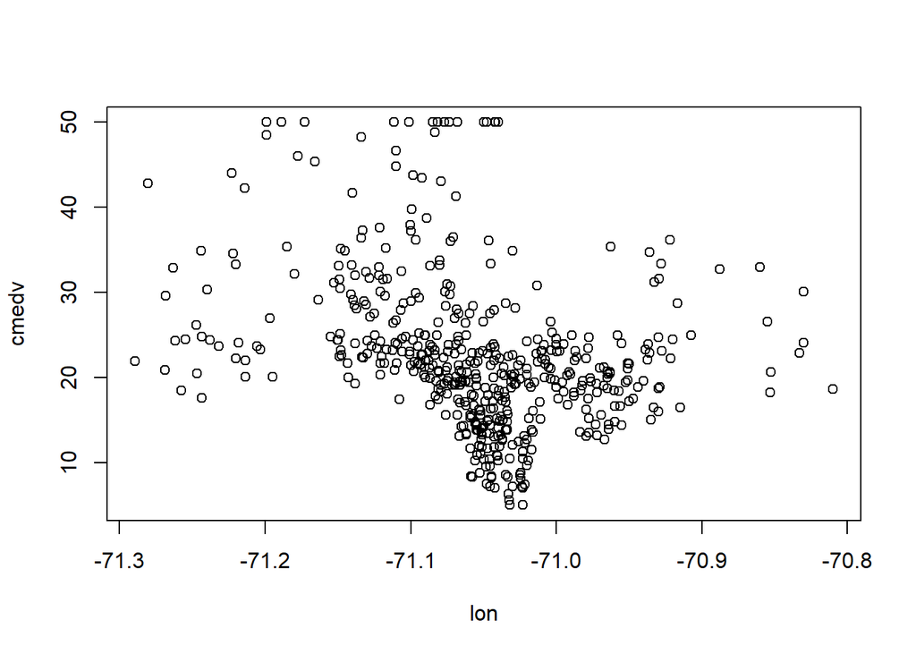

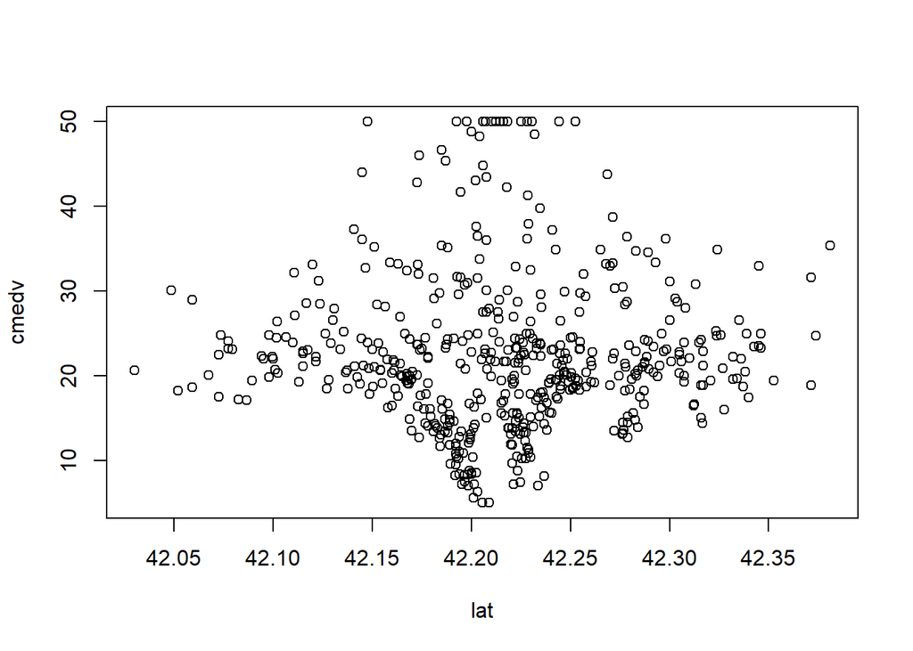

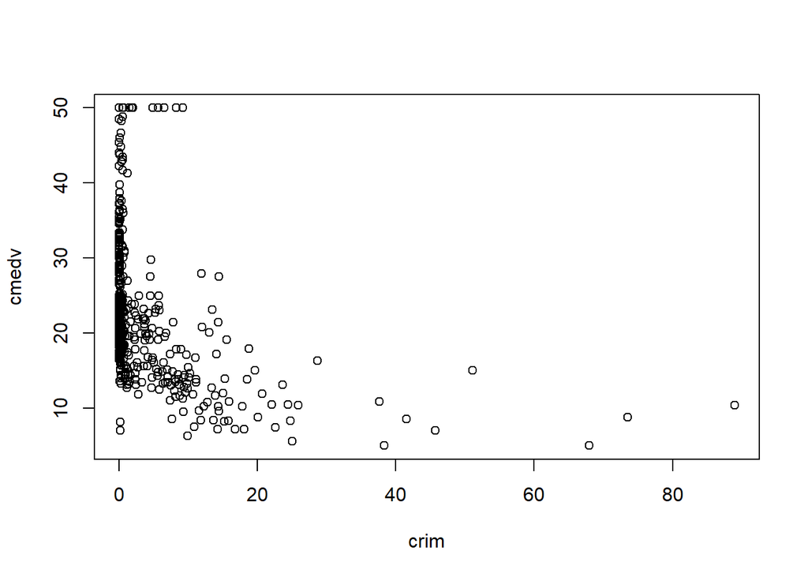

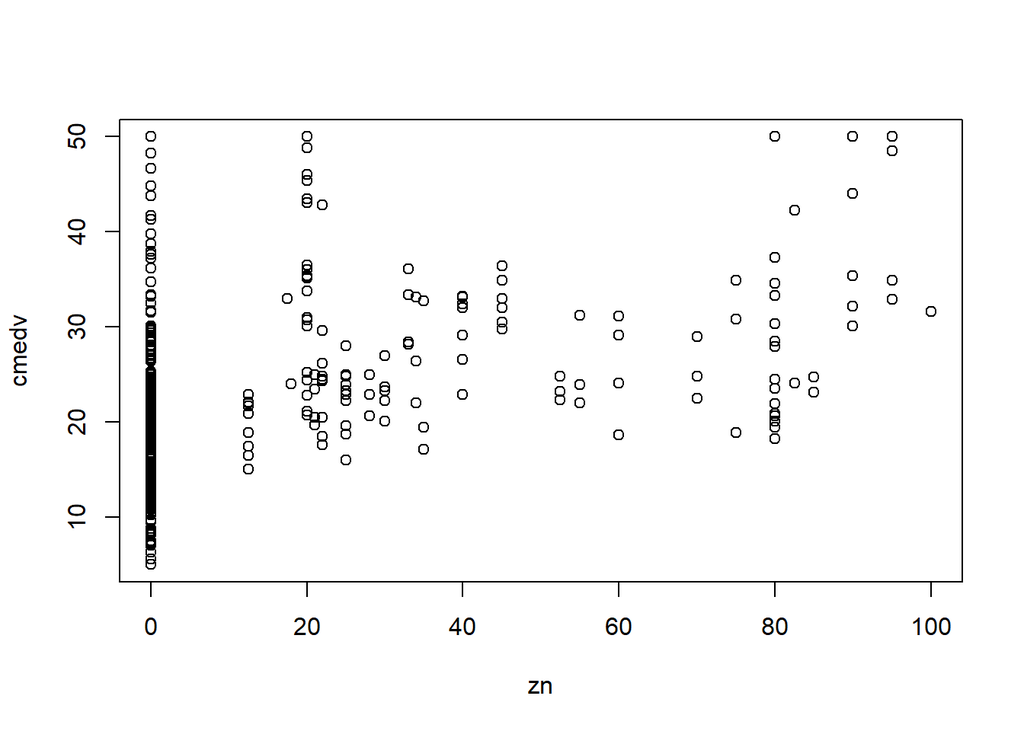

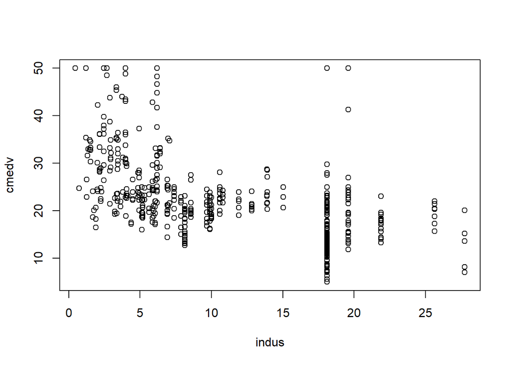

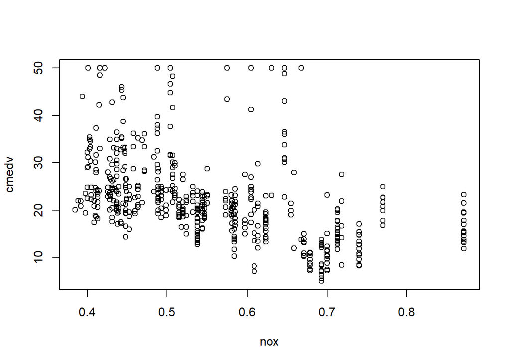

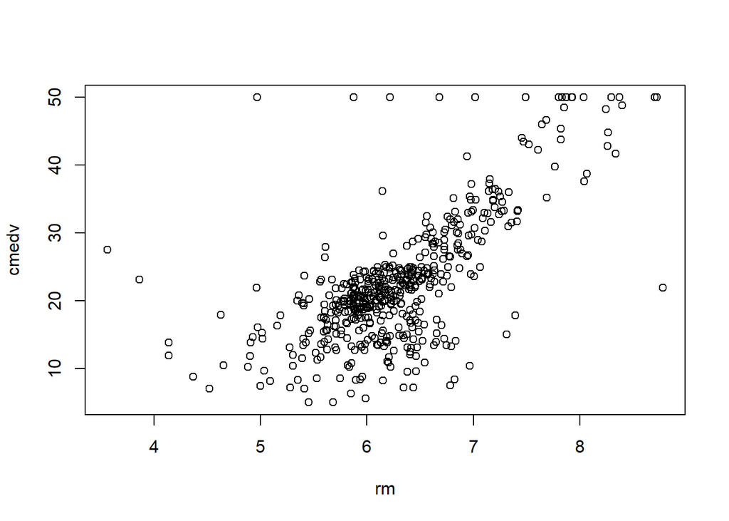

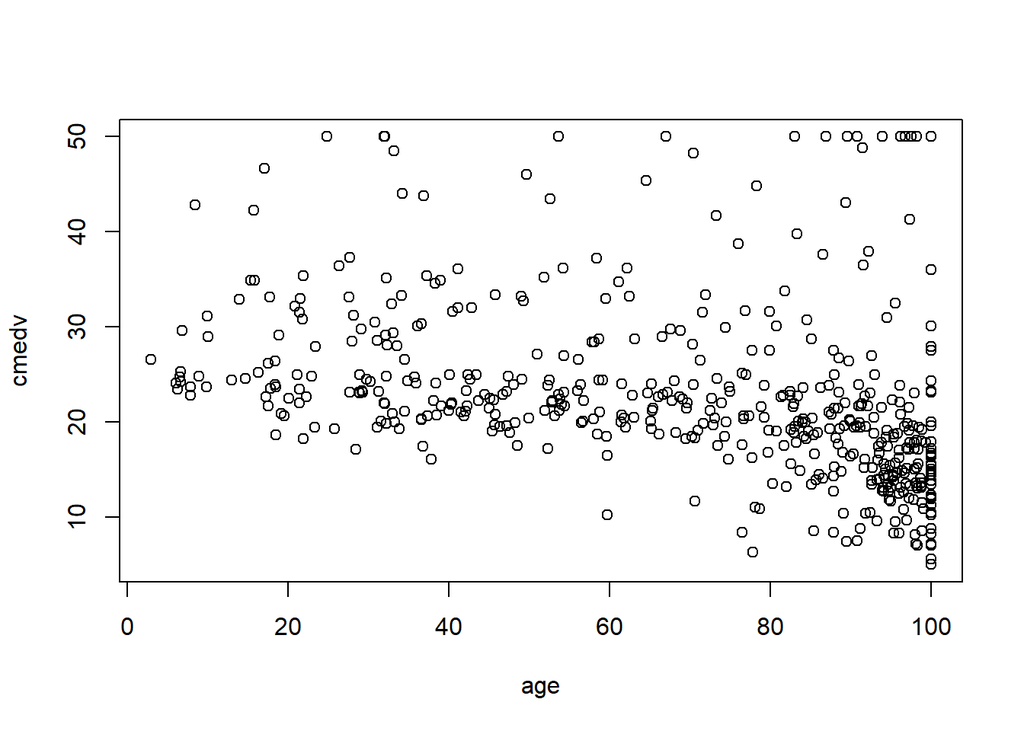

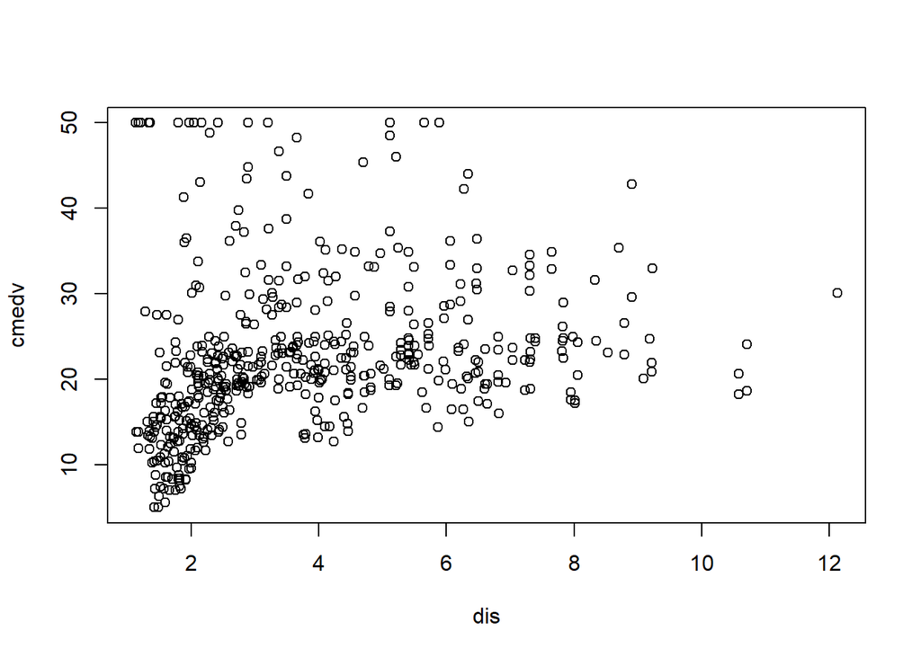

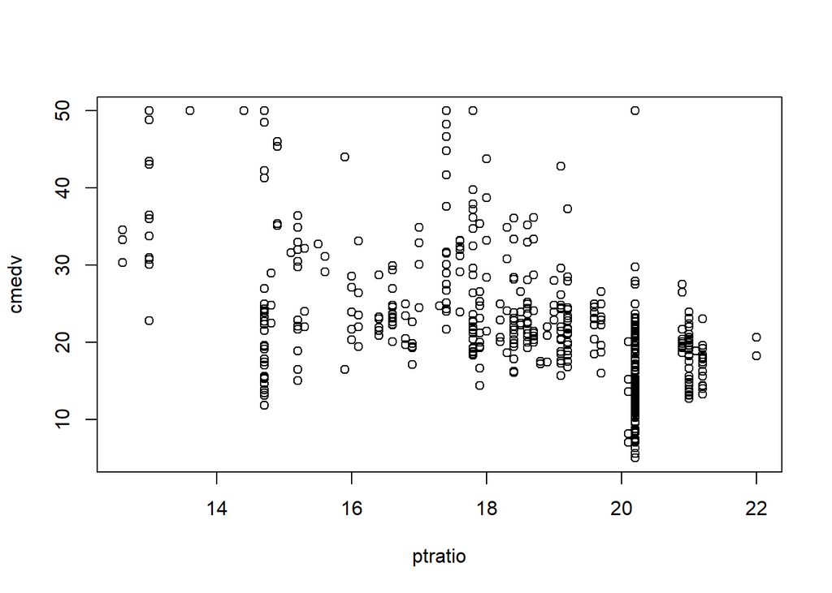

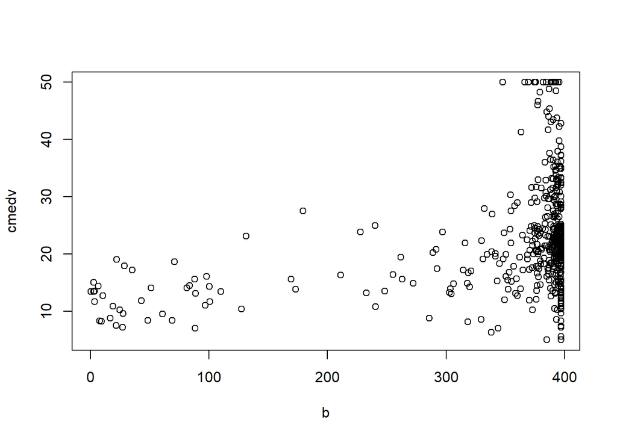

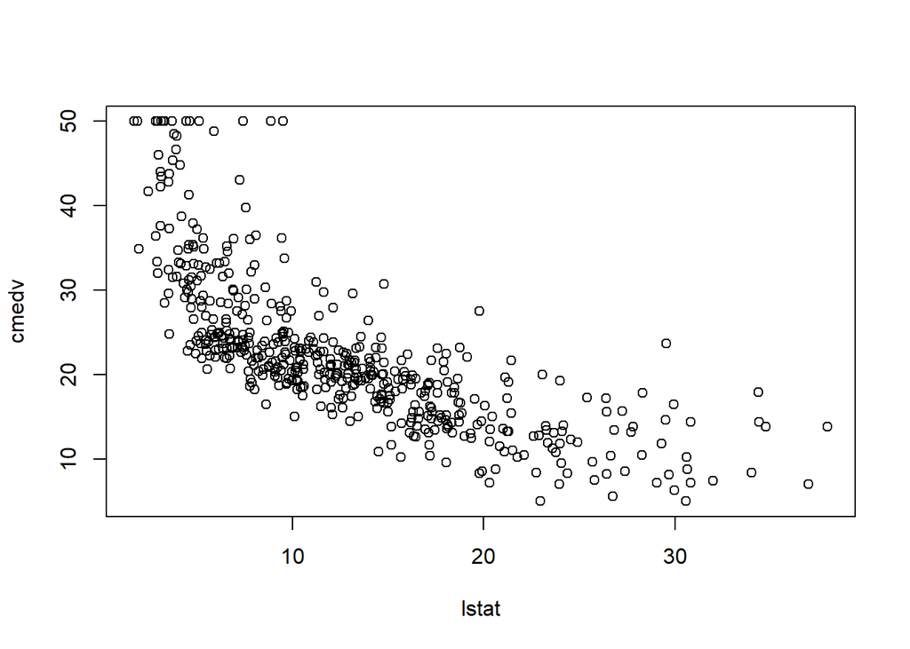

```r
tempY <- x[,5] # Starget cmedv
tempX <- (x[,idxNum])[,-3] # numerical inputs

# Now we produce all the plots
for (i in 1:ncol(tempX)){ # Iterate for each column in tempX
  plot(tempX[,i],tempY,xlab=colnames(tempX)[i],ylab="cmedv")
}
```

- Observation
  - some nice linear relations;
  - lots of noise;
  - some potentially problematic variables (non-linear relations).

### Building a regression model

- Regression Sales on Price

```r
fit1 <- lm(cmedv ~ lstat, data=x)
fit1
```

```
##
## Call:
## lm(formula = cmedv ~ lstat, data = x)
##
## Coefficients:
## (Intercept)        lstat
##     34.5820      -0.9526
```

- Summary of fit1

```r
summary(fit1)
```

```
##
## Call:
## lm(formula = cmedv ~ lstat, data = x)
##
## Residuals:
##    Min     1Q Median     3Q    Max
## -9.951 -3.997 -1.325  2.086 24.496
##
## Coefficients:
##             Estimate Std. Error t value Pr(>|t|)
## (Intercept) 34.58200    0.55882   61.88   <2e-16 ***
## lstat       -0.95259    0.03847  -24.76   <2e-16 ***
## ---
## Signif. codes:  0 '***' 0.001 '**' 0.01 '*' 0.05 '.' 0.1 ' ' 1
##
## Residual standard error: 6.174 on 504 degrees of freedom
## Multiple R-squared:  0.5488, Adjusted R-squared:  0.5479
## F-statistic: 613.1 on 1 and 504 DF,  p-value: < 2.2e-16
```

- Store summary of fit1 to sum1

```r
sum1 <- summary(fit1)
```

```r
names(sum1)
```

```
##  [1] "call"          "terms"         "residuals"     "coefficients"
##  [5] "aliased"       "sigma"         "df"            "r.squared"
##  [9] "adj.r.squared" "fstatistic"    "cov.unscaled"
```

For future reference: within a list you can save any type of variables. These could be vectors, arrays, lists, data.frames, etc. For example, we extract the p-values and test them at 5% significance.

- Fit1 coeffients

```r
# print coeffients
sum1$coefficients
```

```
##               Estimate Std. Error   t value      Pr(>|t|)
## (Intercept) 34.5820044 0.55881606  61.88441 1.264146e-237
## lstat       -0.9525876 0.03847103 -24.76116  3.731519e-89
```

- Evaluate P-Value

```r
pval <- sum1$coefficients[,4]
pval <= 0.05
```

```
## (Intercept)       lstat
##        TRUE        TRUE
```

- Store fit1 $R^{2}$

```r
fit1r2 <- sum1$r.squared
fit1r2
```

```
## [1] 0.548838
```

- Store AIC

```r
fit1aic <- AIC(fit1)
fit1aic
```

```
## [1] 3282.096
```

- Sales on Revenue

```r
# Regress sales on revenue
fit2 <- lm(cmedv~lat,data=x) # Fit the regression model
sum2 <- summary(fit2) # Get summary statistics
sum2
```

```
##
## Call:
## lm(formula = cmedv ~ lat, data = x)
##
## Residuals:
##     Min      1Q  Median      3Q     Max
## -17.521  -5.508  -1.355   2.478  27.541
##
## Coefficients:
##             Estimate Std. Error t value Pr(>|t|)
## (Intercept)  -20.302    279.495  -0.073    0.942
## lat            1.015      6.621   0.153    0.878
##
## Residual standard error: 9.191 on 504 degrees of freedom
## Multiple R-squared:  4.659e-05,  Adjusted R-squared:  -0.001937
## F-statistic: 0.02348 on 1 and 504 DF,  p-value: 0.8783
```

```r
# Get R^2 and AIC
fit2r2 <- sum2$r.squared
fit2aic <- AIC(fit2)

# Test coefficients
sum2$coefficients[,4] <= 0.05
```

```
## (Intercept)         lat
##       FALSE       FALSE
```

- Fit2 Coefficients

```r
sum2$coefficients
```

```
##               Estimate Std. Error     t value  Pr(>|t|)
## (Intercept) -20.301550  279.49509 -0.07263652 0.9421242
## lat           1.014543    6.62052  0.15324222 0.8782686
```

- $R^{2}$ Fit1 vs Fit2

```r
r2 <- c(fit1r2,fit2r2)
r2
```

```
## [1] 5.488380e-01 4.659144e-05
```

- $R^{2}$ value rounding with different decimal places

```r
round(r2,2)
```

```
## [1] 0.55 0.00
```

```r
names(r2) <- c("lstat","lat")
round(r2,3)
```

```
## lstat   lat
## 0.549 0.000
```

- AIC Comparison

```r
aic <- c(fit1aic,fit2aic)
names(aic) <- names(r2)
round(aic,3)
```

```
##    lstat      lat
## 3282.096 3684.813
```

- Sales on Town

```r
# Regress sales on town
fit3 <- lm(cmedv~town,data=x) # Fit the regression model
sum3 <- summary(fit3) # Get summary statistics
sum3
```

```
##
## Call:
## lm(formula = cmedv ~ town, data = x)
##
## Residuals:
##      Min       1Q   Median       3Q      Max
## -15.2250  -2.2458  -0.3083   1.7409  26.3500
##
## Coefficients:
##                             Estimate Std. Error t value Pr(>|t|)
## (Intercept)                  25.2000     2.0376  12.367  < 2e-16 ***
## townAshland                  -3.8000     4.3225  -0.879 0.379840
## townBedford                   4.9000     4.3225   1.134 0.257612
## townBelmont                  11.0000     2.7901   3.942 9.47e-05 ***
## townBeverly                  -4.4000     2.9993  -1.467 0.143133
## townBoston Allston-Brighton  -4.2875     2.7901  -1.537 0.125139
## townBoston Back Bay           7.2000     2.9993   2.401 0.016810 *
## townBoston Beacon Hill       24.8000     3.7202   6.666 8.40e-11 ***
## townBoston Charlestown      -12.5500     2.9993  -4.184 3.49e-05 ***
## townBoston Dorchester        -7.4545     2.6065  -2.860 0.004452 **
## townBoston Downtown          -6.3375     2.7901  -2.271 0.023635 *
## townBoston East Boston      -13.6917     2.5640  -5.340 1.54e-07 ***
## townBoston Forest Hills      -7.8286     2.8816  -2.717 0.006870 **
## townBoston Hyde Park         -4.8250     3.3790  -1.428 0.154066
## townBoston Mattapan          -5.0333     2.9993  -1.678 0.094069 .
## townBoston North End        -11.4000     4.3225  -2.637 0.008669 **
## townBoston Roxbury          -13.5842     2.3836  -5.699 2.29e-08 ***
## townBoston Savin Hill       -11.9652     2.3271  -5.142 4.21e-07 ***
## townBoston South Boston     -16.0769     2.5274  -6.361 5.31e-10 ***
## townBoston West Roxbury      -1.8250     3.3790  -0.540 0.589420
## townBraintree                -2.6250     2.7901  -0.941 0.347348
## townBrookline                12.8250     2.5640   5.002 8.40e-07 ***
## townBurlington               -2.1750     3.3790  -0.644 0.520140
## townCambridge                -1.5500     2.2629  -0.685 0.493750
## townCanton                    1.9667     3.7202   0.529 0.597332
## townChelsea                 -12.4000     3.1567  -3.928 0.000100 ***
## townCohasset                  7.5000     5.7633   1.301 0.193864
## townConcord                   7.5333     3.7202   2.025 0.043509 *
## townDanvers                  -3.0500     3.3790  -0.903 0.367247
## townDedham                    0.1200     3.1567   0.038 0.969694
```

[output cut: 53 more lines]

```
## townWellesley                15.2750     3.3790   4.521 8.06e-06 ***
## townWenham                    6.4000     5.7633   1.110 0.267436
## townWeston                   24.0500     4.3225   5.564 4.74e-08 ***
## townWestwood                  6.0333     3.7202   1.622 0.105610
## townWeymouth                 -5.1625     2.7901  -1.850 0.064987 .
## townWilmington               -5.1000     3.7202  -1.371 0.171148
## townWinchester                7.9000     3.1567   2.503 0.012712 *
## townWinthrop                 -3.6200     3.1567  -1.147 0.252136
## townWoburn                   -3.9000     2.9993  -1.300 0.194220
## ---
## Signif. codes:  0 '***' 0.001 '**' 0.01 '*' 0.05 '.' 0.1 ' ' 1
##
## Residual standard error: 5.391 on 414 degrees of freedom
## Multiple R-squared:  0.7174, Adjusted R-squared:  0.6553
## F-statistic: 11.55 on 91 and 414 DF,  p-value: < 2.2e-16
```

```r
# Get R^2 and AIC
fit3r2 <- sum3$r.squared
fit3aic <- AIC(fit3)
```

- Sales on Price with and without Intercept

```r
# Model with intercept
lm(cmedv ~ lstat, data=x)
```

```
##
## Call:
## lm(formula = cmedv ~ lstat, data = x)
##
## Coefficients:
## (Intercept)        lstat
##     34.5820      -0.9526
```

```r
# Model without intercept
lm(cmedv ~ 0 + lstat, data=x)
```

```
##
## Call:
## lm(formula = cmedv ~ 0 + lstat, data = x)
##
## Coefficients:
## lstat
## 1.121
```

Observe that the second model, which uses 0 + … in the formula, removes the intercept.

### Multiple regression

- Sales on Price + Revenue

```r
fit4 <- lm(cmedv~lstat+lat,data=x)
sum4 <- summary(fit4)
sum4
```

```
##
## Call:
## lm(formula = cmedv ~ lstat + lat, data = x)
##
## Residuals:
##    Min     1Q Median     3Q    Max
## -9.903 -4.155 -1.386  2.062 24.491
##
## Coefficients:
##               Estimate Std. Error t value Pr(>|t|)
## (Intercept) -221.00354  187.75285  -1.177    0.240
## lstat         -0.95498    0.03848 -24.818   <2e-16 ***
## lat            6.05489    4.44789   1.361    0.174
## ---
## Signif. codes:  0 '***' 0.001 '**' 0.01 '*' 0.05 '.' 0.1 ' ' 1
##
## Residual standard error: 6.168 on 503 degrees of freedom
## Multiple R-squared:  0.5505, Adjusted R-squared:  0.5487
## F-statistic:   308 on 2 and 503 DF,  p-value: < 2.2e-16
```

- Sales vs Random inputs - Demonstrate $R^{2}$ variations

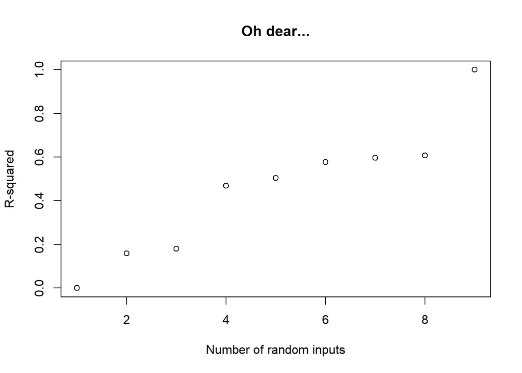

```r
# Create a variable yy that includes the first 10 values of
# cmedv, our target variable
yy <- x[,colnames(x)=="cmedv"]
yy <- yy[1:10]
# Now create a matrix with 9 columns of random data
# The function runif() creates random draws from a uniform
# distirbution
xx <- matrix(runif(90),ncol=9) # Draw 100 values and put them
                               # in a matrix with 10 columns
# Loop for all regressions from 1 to 9 inputs
ftemp <- list() # Pre-allocate a list to save the results
for (i in 1:9){
  ftemp[[i]] <- lm(yy ~xx[,1:i])
}
# Get R-squared from all models
r2temp <- unlist(lapply(ftemp,function(x){summary(x)$r.squared}))
plot(1:9,r2temp,xlab="Number of random inputs",ylab="R-squared",main="Oh dear...")
```

- AIC vlues

```r
sapply(ftemp,AIC)
```

```
## [1] 72.00265 72.26531 74.00677 71.68310 72.98986 73.41714 74.94301 76.65038
## [9]     -Inf
```

- Error fitted values

```r
yy - ftemp[[9]]$fitted.values
```

```
##  1  2  3  4  5  6  7  8  9 10
##  0  0  0  0  0  0  0  0  0  0
```

- Model with just a constant

```r
ftemp[[10]] <- lm(yy~1) # This means just fit a constant
sapply(ftemp,AIC)
```

```
##  [1] 72.00265 72.26531 74.00677 71.68310 72.98986 73.41714 74.94301 76.65038
##  [9]     -Inf 70.00286
```

- Check $R^{2}$

```r
unlist(lapply(ftemp,function(x){summary(x)$r.squared}))
```

```
##  [1] 2.110999e-05 1.594968e-01 1.809491e-01 4.684594e-01 5.040599e-01
##  [6] 5.762330e-01 5.958563e-01 6.075112e-01 1.000000e+00 0.000000e+00
```

### Variable selection

- cmedv vs all variables

```r
fit5 <- lm(cmedv~.,data=x)
summary(fit5)
```

```
##
## Call:
## lm(formula = cmedv ~ ., data = x)
##
## Residuals:
##      Min       1Q   Median       3Q      Max
## -26.7502  -1.3118   0.0000   0.9575  16.8532
##
## Coefficients: (5 not defined because of singularities)
##                               Estimate Std. Error t value Pr(>|t|)
## (Intercept)                  9.096e+02  1.593e+03   0.571  0.56837
## townAshland                 -1.304e+01  9.063e+00  -1.439  0.15088
## townBedford                 -1.646e+00  3.402e+00  -0.484  0.62879
## townBelmont                  7.250e+00  1.773e+00   4.089 5.24e-05 ***
## townBeverly                  3.927e+01  3.919e+01   1.002  0.31693
## townBoston Allston-Brighton  1.103e+02  9.732e+01   1.134  0.25768
## townBoston Back Bay          1.182e+02  9.474e+01   1.248  0.21292
## townBoston Beacon Hill       1.269e+02  9.208e+01   1.378  0.16904
## townBoston Charlestown       8.492e+01  8.650e+01   0.982  0.32686
## townBoston Dorchester        7.554e+01  7.017e+01   1.077  0.28231
## townBoston Downtown          8.945e+01  7.834e+01   1.142  0.25421
## townBoston East Boston       9.016e+01  8.396e+01   1.074  0.28349
## townBoston Forest Hills      6.701e+01  6.476e+01   1.035  0.30143
## townBoston Hyde Park         6.074e+01  5.954e+01   1.020  0.30824
## townBoston Mattapan          7.080e+01  6.763e+01   1.047  0.29580
## townBoston North End         1.035e+02  8.939e+01   1.158  0.24740
## townBoston Roxbury           7.829e+01  7.542e+01   1.038  0.29988
## townBoston Savin Hill        7.599e+01  7.259e+01   1.047  0.29581
## townBoston South Boston      8.015e+01  8.099e+01   0.990  0.32292
## townBoston West Roxbury      6.296e+01  6.226e+01   1.011  0.31252
## townBraintree               -2.407e+01  1.713e+01  -1.405  0.16066
## townBrookline               -3.265e+00  1.250e+01  -0.261  0.79402
## townBurlington               1.728e+00  7.370e+00   0.234  0.81478
## townCambridge                9.608e+00  1.885e+00   5.096 5.35e-07 ***
## townCanton                  -2.311e+01  1.606e+01  -1.439  0.15100
## townChelsea                  5.448e+01  5.378e+01   1.013  0.31168
## townCohasset                -2.031e+01  1.835e+01  -1.107  0.26906
## townConcord                  2.694e-01  3.848e+00   0.070  0.94421
## townDanvers                  4.045e+01  4.069e+01   0.994  0.32085
## townDedham                  -1.725e+01  1.264e+01  -1.365  0.17292
```

[output cut: 69 more lines]

```
## nox                         -2.918e+01  4.909e+00  -5.943 6.07e-09 ***
## rm                           5.144e+00  3.624e-01  14.194  < 2e-16 ***
## age                         -5.959e-02  1.196e-02  -4.980 9.45e-07 ***
## dis                         -8.236e-01  5.396e-01  -1.526  0.12773
## rad                                 NA         NA      NA       NA
## tax                                 NA         NA      NA       NA
## ptratio                             NA         NA      NA       NA
## b                            1.382e-02  2.613e-03   5.287 2.04e-07 ***
## lstat                       -2.194e-01  4.723e-02  -4.646 4.59e-06 ***
## ---
## Signif. codes:  0 '***' 0.001 '**' 0.01 '*' 0.05 '.' 0.1 ' ' 1
##
## Residual standard error: 3.265 on 403 degrees of freedom
## Multiple R-squared:  0.8991, Adjusted R-squared:  0.8735
## F-statistic:  35.2 on 102 and 403 DF,  p-value: < 2.2e-16
```

- cmedv with only intercept - fitmin

```r
fitmin <- lm(cmedv~1,data=x) # This means use only an intercept.
```

- Bidirectional model combining fitmin and fit5(all)

```r
fit6 <- step(fitmin,direction="both",scope=formula(fit5))
```

```
## Start:  AIC=2244.87
## cmedv ~ 1
##
##           Df Sum of Sq   RSS    AIC
## + town    91   30545.5 12032 1787.4
## + lstat    1   23368.3 19209 1844.1
## + rm       1   20643.3 21934 1911.2
## + ptratio  1   10886.6 31691 2097.4
## + indus    1   10005.2 32573 2111.3
## + tax      1    9484.8 33093 2119.3
## + nox      1    7847.0 34731 2143.8
## + tract    1    7808.7 34769 2144.3
## + crim     1    6462.2 36116 2163.6
## + rad      1    6303.4 36274 2165.8
## + age      1    6083.6 36494 2168.8
## + zn       1    5529.9 37048 2176.5
## + b        1    4774.3 37803 2186.7
## + lon      1    4440.6 38137 2191.1
## + dis      1    2646.5 39931 2214.4
## + chas     1    1313.8 41264 2231.0
## <none>                 42578 2244.9
## + lat      1       2.0 42576 2246.8
##
## Step:  AIC=1787.42
## cmedv ~ town
##
##         Df Sum of Sq   RSS    AIC
## + rm     1    5704.0  6328 1464.3
## + lstat  1    4752.3  7280 1535.2
## + nox    1    2110.9  9921 1691.8
## + age    1     815.4 11217 1753.9
## + b      1     589.3 11443 1764.0
## + dis    1     471.5 11561 1769.2
## + lon    1     388.1 11644 1772.8
## + crim   1     230.1 11802 1779.7
## + tract  1     193.4 11839 1781.2
## + lat    1      48.1 11984 1787.4
## <none>               12032 1787.4
## + chas   1       6.4 12026 1789.2
## - town  91   30545.5 42578 2244.9
```

[output cut: 111 more lines]

```
##
##         Df Sum of Sq     RSS    AIC
## <none>                4320.7 1283.2
## + tract  1      14.7  4306.1 1283.5
## - dis    1      19.5  4340.3 1283.5
## + lat    1       9.2  4311.6 1284.1
## - chas   1      28.6  4349.3 1284.5
## + crim   1       2.0  4318.7 1285.0
## + lon    1       1.7  4319.0 1285.0
## - lstat  1     224.1  4544.8 1306.8
## - age    1     260.3  4581.0 1310.8
## - b      1     313.6  4634.3 1316.6
## - nox    1     464.1  4784.8 1332.8
## - rm     1    2178.0  6498.7 1487.7
## - town  91    9048.7 13369.4 1672.7
```

- Fit6 summary

```r
summary(fit6)
```

```
##
## Call:
## lm(formula = cmedv ~ town + rm + lstat + nox + b + age + chas +
##     dis, data = x)
##
## Residuals:
##      Min       1Q   Median       3Q      Max
## -26.8015  -1.2470  -0.0179   0.9426  16.8967
##
## Coefficients:
##                               Estimate Std. Error t value Pr(>|t|)
## (Intercept)                  10.982721   4.230786   2.596 0.009776 **
## townAshland                  -4.394169   4.090273  -1.074 0.283326
## townBedford                  -2.389648   3.090451  -0.773 0.439832
## townBelmont                   7.768241   1.700326   4.569 6.52e-06 ***
## townBeverly                  -3.026896   2.858750  -1.059 0.290311
## townBoston Allston-Brighton   6.846599   2.070443   3.307 0.001027 **
## townBoston Back Bay          17.823629   2.118133   8.415 6.76e-16 ***
## townBoston Beacon Hill       29.277647   2.537023  11.540  < 2e-16 ***
## townBoston Charlestown       -7.202711   2.100746  -3.429 0.000669 ***
## townBoston Dorchester         2.205005   1.806961   1.220 0.223064
## townBoston Downtown           6.551903   1.949771   3.360 0.000852 ***
## townBoston East Boston        1.004088   1.817590   0.552 0.580958
## townBoston Forest Hills      -1.005363   1.829730  -0.549 0.582991
## townBoston Hyde Park         -0.953817   2.106608  -0.453 0.650953
## townBoston Mattapan           0.006125   1.845075   0.003 0.997353
## townBoston North End          8.640409   2.869271   3.011 0.002763 **
## townBoston Roxbury           -1.305000   1.793701  -0.728 0.467310
## townBoston Savin Hill        -0.323253   1.781587  -0.181 0.856112
## townBoston South Boston      -5.453970   1.800604  -3.029 0.002610 **
## townBoston West Roxbury      -2.065803   2.070342  -0.998 0.318966
## townBraintree                -3.265402   1.958017  -1.668 0.096143 .
## townBrookline                10.818405   1.751904   6.175 1.60e-09 ***
## townBurlington               -6.687729   2.415190  -2.769 0.005879 **
## townCambridge                 9.616578   1.779954   5.403 1.12e-07 ***
## townCanton                   -3.583020   2.599126  -1.379 0.168791
## townChelsea                  -2.433715   2.018035  -1.206 0.228525
## townCohasset                  1.309491   4.024364   0.325 0.745052
## townConcord                   0.121186   3.115536   0.039 0.968991
## townDanvers                  -3.755980   2.817115  -1.333 0.183188
```

[output cut: 61 more lines]

```
## townWinthrop                 -2.995073   1.959028  -1.529 0.127077
## townWoburn                   -5.909296   1.976387  -2.990 0.002960 **
## rm                            5.141924   0.358986  14.323  < 2e-16 ***
## lstat                        -0.215062   0.046807  -4.595 5.79e-06 ***
## nox                         -30.197923   4.567205  -6.612 1.19e-10 ***
## b                             0.013917   0.002561   5.435 9.47e-08 ***
## age                          -0.057944   0.011702  -4.952 1.08e-06 ***
## chas1                        -1.226567   0.747364  -1.641 0.101530
## dis                          -0.701003   0.516611  -1.357 0.175556
## ---
## Signif. codes:  0 '***' 0.001 '**' 0.01 '*' 0.05 '.' 0.1 ' ' 1
##
## Residual standard error: 3.258 on 407 degrees of freedom
## Multiple R-squared:  0.8985, Adjusted R-squared:  0.8741
## F-statistic: 36.77 on 98 and 407 DF,  p-value: < 2.2e-16
```

- Forward directional model combining fitmin and fit5(all)

```r
fit7 <- step(fitmin,direction="forward",scope=formula(fit5))
```

```
## Start:  AIC=2244.87
## cmedv ~ 1
##
##           Df Sum of Sq   RSS    AIC
## + town    91   30545.5 12032 1787.4
## + lstat    1   23368.3 19209 1844.1
## + rm       1   20643.3 21934 1911.2
## + ptratio  1   10886.6 31691 2097.4
## + indus    1   10005.2 32573 2111.3
## + tax      1    9484.8 33093 2119.3
## + nox      1    7847.0 34731 2143.8
## + tract    1    7808.7 34769 2144.3
## + crim     1    6462.2 36116 2163.6
## + rad      1    6303.4 36274 2165.8
## + age      1    6083.6 36494 2168.8
## + zn       1    5529.9 37048 2176.5
## + b        1    4774.3 37803 2186.7
## + lon      1    4440.6 38137 2191.1
## + dis      1    2646.5 39931 2214.4
## + chas     1    1313.8 41264 2231.0
## <none>                 42578 2244.9
## + lat      1       2.0 42576 2246.8
##
## Step:  AIC=1787.42
## cmedv ~ town
##
##         Df Sum of Sq     RSS    AIC
## + rm     1    5704.0  6328.2 1464.3
## + lstat  1    4752.3  7280.0 1535.2
## + nox    1    2110.9  9921.3 1691.8
## + age    1     815.4 11216.8 1753.9
## + b      1     589.3 11442.9 1764.0
## + dis    1     471.5 11560.7 1769.2
## + lon    1     388.1 11644.1 1772.8
## + crim   1     230.1 11802.2 1779.7
## + tract  1     193.4 11838.8 1781.2
## + lat    1      48.1 11984.1 1787.4
## <none>               12032.2 1787.4
## + chas   1       6.4 12025.8 1789.2
##
```

[output cut: 75 more lines]

```
## <none>               4340.3 1283.5
## + tract  1    9.5423 4330.7 1284.4
## + lat    1    6.4590 4333.8 1284.7
## + lon    1    4.5097 4335.8 1285.0
## + crim   1    1.3872 4338.9 1285.3
##
## Step:  AIC=1283.19
## cmedv ~ town + rm + lstat + nox + b + age + chas + dis
##
##         Df Sum of Sq    RSS    AIC
## <none>               4320.7 1283.2
## + tract  1   14.6700 4306.1 1283.5
## + lat    1    9.1782 4311.6 1284.1
## + crim   1    2.0154 4318.7 1285.0
## + lon    1    1.6876 4319.0 1285.0
```

- Summary of Forward directional model fit7

```r
summary(fit7)
```

```
##
## Call:
## lm(formula = cmedv ~ town + rm + lstat + nox + b + age + chas +
##     dis, data = x)
##
## Residuals:
##      Min       1Q   Median       3Q      Max
## -26.8015  -1.2470  -0.0179   0.9426  16.8967
##
## Coefficients:
##                               Estimate Std. Error t value Pr(>|t|)
## (Intercept)                  10.982721   4.230786   2.596 0.009776 **
## townAshland                  -4.394169   4.090273  -1.074 0.283326
## townBedford                  -2.389648   3.090451  -0.773 0.439832
## townBelmont                   7.768241   1.700326   4.569 6.52e-06 ***
## townBeverly                  -3.026896   2.858750  -1.059 0.290311
## townBoston Allston-Brighton   6.846599   2.070443   3.307 0.001027 **
## townBoston Back Bay          17.823629   2.118133   8.415 6.76e-16 ***
## townBoston Beacon Hill       29.277647   2.537023  11.540  < 2e-16 ***
## townBoston Charlestown       -7.202711   2.100746  -3.429 0.000669 ***
## townBoston Dorchester         2.205005   1.806961   1.220 0.223064
## townBoston Downtown           6.551903   1.949771   3.360 0.000852 ***
## townBoston East Boston        1.004088   1.817590   0.552 0.580958
## townBoston Forest Hills      -1.005363   1.829730  -0.549 0.582991
## townBoston Hyde Park         -0.953817   2.106608  -0.453 0.650953
## townBoston Mattapan           0.006125   1.845075   0.003 0.997353
## townBoston North End          8.640409   2.869271   3.011 0.002763 **
## townBoston Roxbury           -1.305000   1.793701  -0.728 0.467310
## townBoston Savin Hill        -0.323253   1.781587  -0.181 0.856112
## townBoston South Boston      -5.453970   1.800604  -3.029 0.002610 **
## townBoston West Roxbury      -2.065803   2.070342  -0.998 0.318966
## townBraintree                -3.265402   1.958017  -1.668 0.096143 .
## townBrookline                10.818405   1.751904   6.175 1.60e-09 ***
## townBurlington               -6.687729   2.415190  -2.769 0.005879 **
## townCambridge                 9.616578   1.779954   5.403 1.12e-07 ***
## townCanton                   -3.583020   2.599126  -1.379 0.168791
## townChelsea                  -2.433715   2.018035  -1.206 0.228525
## townCohasset                  1.309491   4.024364   0.325 0.745052
## townConcord                   0.121186   3.115536   0.039 0.968991
## townDanvers                  -3.755980   2.817115  -1.333 0.183188
```

[output cut: 61 more lines]

```
## townWinthrop                 -2.995073   1.959028  -1.529 0.127077
## townWoburn                   -5.909296   1.976387  -2.990 0.002960 **
## rm                            5.141924   0.358986  14.323  < 2e-16 ***
## lstat                        -0.215062   0.046807  -4.595 5.79e-06 ***
## nox                         -30.197923   4.567205  -6.612 1.19e-10 ***
## b                             0.013917   0.002561   5.435 9.47e-08 ***
## age                          -0.057944   0.011702  -4.952 1.08e-06 ***
## chas1                        -1.226567   0.747364  -1.641 0.101530
## dis                          -0.701003   0.516611  -1.357 0.175556
## ---
## Signif. codes:  0 '***' 0.001 '**' 0.01 '*' 0.05 '.' 0.1 ' ' 1
##
## Residual standard error: 3.258 on 407 degrees of freedom
## Multiple R-squared:  0.8985, Adjusted R-squared:  0.8741
## F-statistic: 36.77 on 98 and 407 DF,  p-value: < 2.2e-16
```

- Backward directional model combining fitmin and fit5(all)

```r
fit8 <- step(fit5,direction="backward",scope=formula(fit5))
```

```
## Start:  AIC=1288.39
## cmedv ~ town + tract + lon + lat + crim + zn + indus + chas +
##     nox + rm + age + dis + rad + tax + ptratio + b + lstat
##
##
## Step:  AIC=1288.39
## cmedv ~ town + tract + lon + lat + crim + zn + indus + chas +
##     nox + rm + age + dis + rad + tax + b + lstat
##
##
## Step:  AIC=1288.39
## cmedv ~ town + tract + lon + lat + crim + zn + indus + chas +
##     nox + rm + age + dis + rad + b + lstat
##
##
## Step:  AIC=1288.39
## cmedv ~ town + tract + lon + lat + crim + zn + indus + chas +
##     nox + rm + age + dis + b + lstat
##
##
## Step:  AIC=1288.39
## cmedv ~ town + tract + lon + lat + crim + zn + chas + nox + rm +
##     age + dis + b + lstat
##
##
## Step:  AIC=1288.39
## cmedv ~ town + tract + lon + lat + crim + chas + nox + rm + age +
##     dis + b + lstat
##
##         Df Sum of Sq     RSS    AIC
## - lon    1       0.4  4297.3 1286.4
## - crim   1       1.2  4298.2 1286.5
## - lat    1       6.7  4303.6 1287.2
## - tract  1      12.2  4309.1 1287.8
## <none>                4296.9 1288.4
## - dis    1      24.8  4321.8 1289.3
## - chas   1      26.2  4323.1 1289.5
## - lstat  1     230.1  4527.1 1312.8
## - age    1     264.4  4561.4 1316.6
## - b      1     298.1  4595.0 1320.3
```

[output cut: 52 more lines]

```
## - town  91    8988.4 13294.5 1671.9
##
## Step:  AIC=1283.19
## cmedv ~ town + chas + nox + rm + age + dis + b + lstat
##
##         Df Sum of Sq     RSS    AIC
## <none>                4320.7 1283.2
## - dis    1      19.5  4340.3 1283.5
## - chas   1      28.6  4349.3 1284.5
## - lstat  1     224.1  4544.8 1306.8
## - age    1     260.3  4581.0 1310.8
## - b      1     313.6  4634.3 1316.6
## - nox    1     464.1  4784.8 1332.8
## - rm     1    2178.0  6498.7 1487.7
## - town  91    9048.7 13369.4 1672.7
```

- Summary backward directional model

```r
summary(fit8)
```

```
##
## Call:
## lm(formula = cmedv ~ town + chas + nox + rm + age + dis + b +
##     lstat, data = x)
##
## Residuals:
##      Min       1Q   Median       3Q      Max
## -26.8015  -1.2470  -0.0179   0.9426  16.8967
##
## Coefficients:
##                               Estimate Std. Error t value Pr(>|t|)
## (Intercept)                  10.982721   4.230786   2.596 0.009776 **
## townAshland                  -4.394169   4.090273  -1.074 0.283326
## townBedford                  -2.389648   3.090451  -0.773 0.439832
## townBelmont                   7.768241   1.700326   4.569 6.52e-06 ***
## townBeverly                  -3.026896   2.858750  -1.059 0.290311
## townBoston Allston-Brighton   6.846599   2.070443   3.307 0.001027 **
## townBoston Back Bay          17.823629   2.118133   8.415 6.76e-16 ***
## townBoston Beacon Hill       29.277647   2.537023  11.540  < 2e-16 ***
## townBoston Charlestown       -7.202711   2.100746  -3.429 0.000669 ***
## townBoston Dorchester         2.205005   1.806961   1.220 0.223064
## townBoston Downtown           6.551903   1.949771   3.360 0.000852 ***
## townBoston East Boston        1.004088   1.817590   0.552 0.580958
## townBoston Forest Hills      -1.005363   1.829730  -0.549 0.582991
## townBoston Hyde Park         -0.953817   2.106608  -0.453 0.650953
## townBoston Mattapan           0.006125   1.845075   0.003 0.997353
## townBoston North End          8.640409   2.869271   3.011 0.002763 **
## townBoston Roxbury           -1.305000   1.793701  -0.728 0.467310
## townBoston Savin Hill        -0.323253   1.781587  -0.181 0.856112
## townBoston South Boston      -5.453970   1.800604  -3.029 0.002610 **
## townBoston West Roxbury      -2.065803   2.070342  -0.998 0.318966
## townBraintree                -3.265402   1.958017  -1.668 0.096143 .
## townBrookline                10.818405   1.751904   6.175 1.60e-09 ***
## townBurlington               -6.687729   2.415190  -2.769 0.005879 **
## townCambridge                 9.616578   1.779954   5.403 1.12e-07 ***
## townCanton                   -3.583020   2.599126  -1.379 0.168791
## townChelsea                  -2.433715   2.018035  -1.206 0.228525
## townCohasset                  1.309491   4.024364   0.325 0.745052
## townConcord                   0.121186   3.115536   0.039 0.968991
## townDanvers                  -3.755980   2.817115  -1.333 0.183188
```

[output cut: 61 more lines]

```
## townWinthrop                 -2.995073   1.959028  -1.529 0.127077
## townWoburn                   -5.909296   1.976387  -2.990 0.002960 **
## chas1                        -1.226567   0.747364  -1.641 0.101530
## nox                         -30.197923   4.567205  -6.612 1.19e-10 ***
## rm                            5.141924   0.358986  14.323  < 2e-16 ***
## age                          -0.057944   0.011702  -4.952 1.08e-06 ***
## dis                          -0.701003   0.516611  -1.357 0.175556
## b                             0.013917   0.002561   5.435 9.47e-08 ***
## lstat                        -0.215062   0.046807  -4.595 5.79e-06 ***
## ---
## Signif. codes:  0 '***' 0.001 '**' 0.01 '*' 0.05 '.' 0.1 ' ' 1
##
## Residual standard error: 3.258 on 407 degrees of freedom
## Multiple R-squared:  0.8985, Adjusted R-squared:  0.8741
## F-statistic: 36.77 on 98 and 407 DF,  p-value: < 2.2e-16
```

- Compare fit1, fit2, fit5, fit6, fit7 and fit8

```r
aic <- c(AIC(fit1),AIC(fit2),AIC(fit5),AIC(fit6),AIC(fit7),AIC(fit8))
names(aic) <- c(formula(fit1),formula(fit2),"Full model","Stepwise","Forward","Backward")
round(aic,4)
```

```
## cmedv ~ lstat   cmedv ~ lat    Full model      Stepwise       Forward
##      3282.096      3684.813      2726.360      2721.155      2721.155
##      Backward
##      2721.155
```

- Summary of Fit6

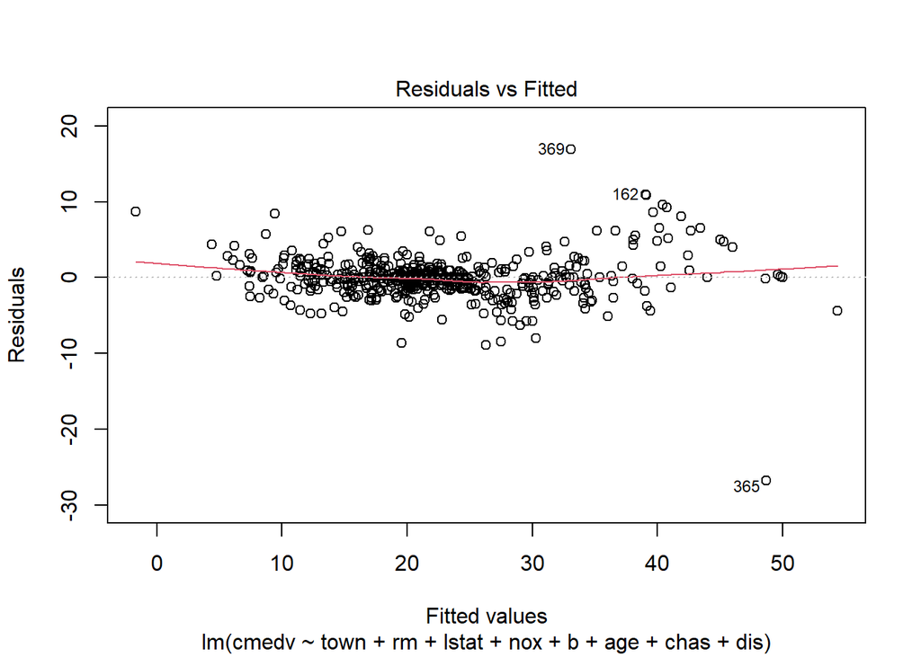

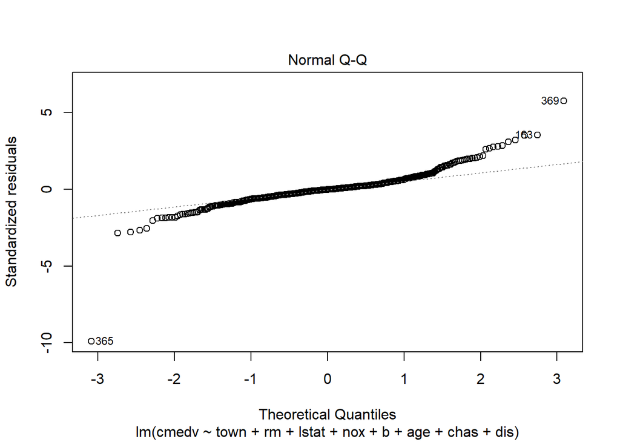

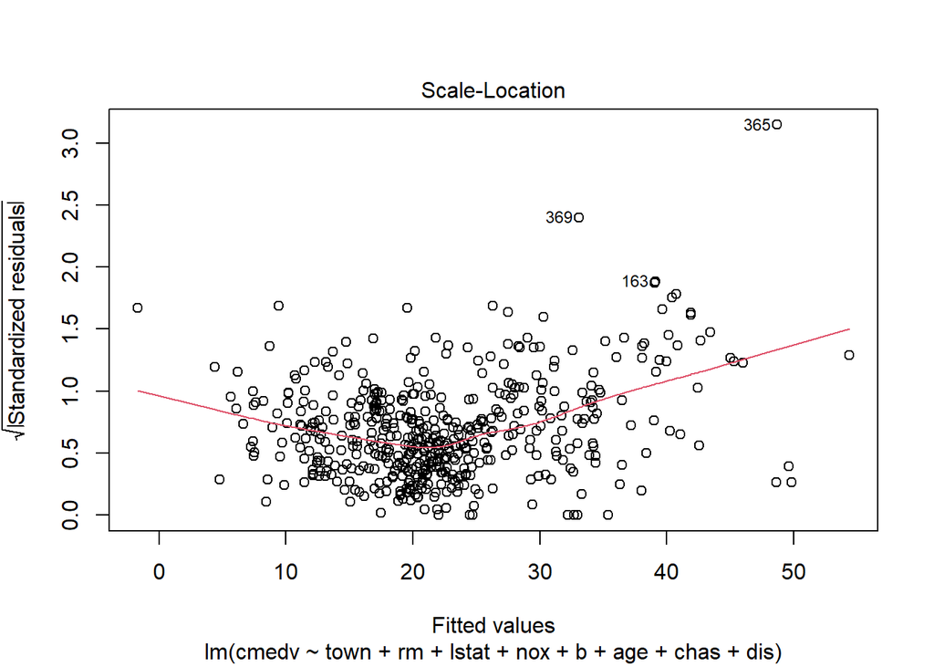

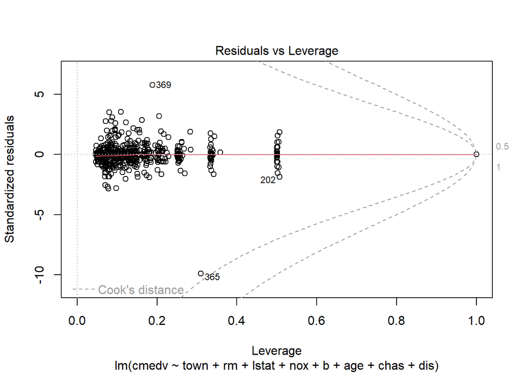

```r
plot(fit6)
```

- Fit all the plots for fit6

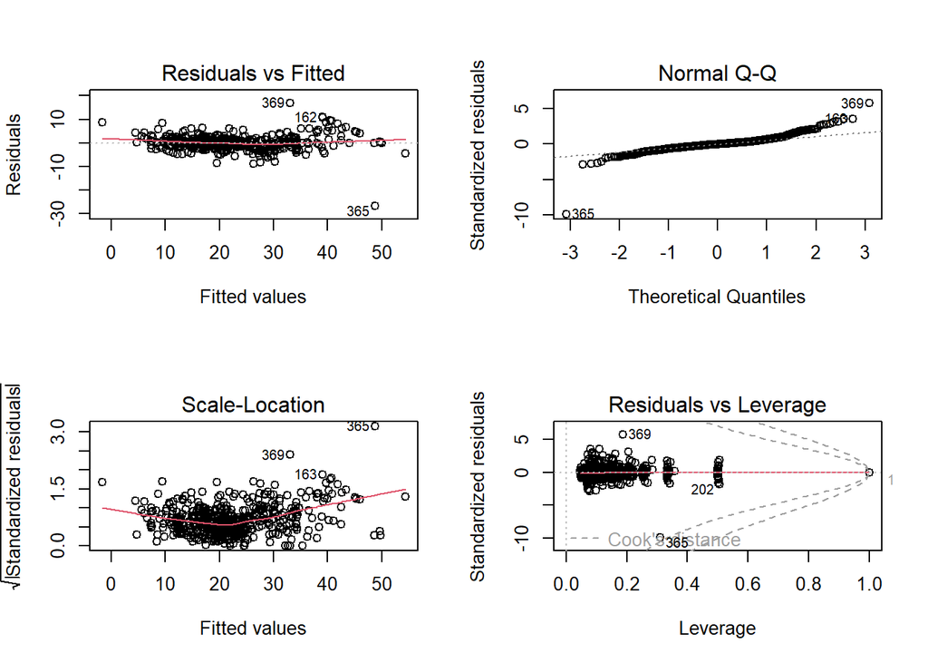

```r
par(mfrow=c(2,2))
plot(fit6) # Plot
```

```r
par(mfrow=c(1,1))
```

```r
resid <- fit6$residuals
fitted <- fit6$fitted.values
```

And produce the plots

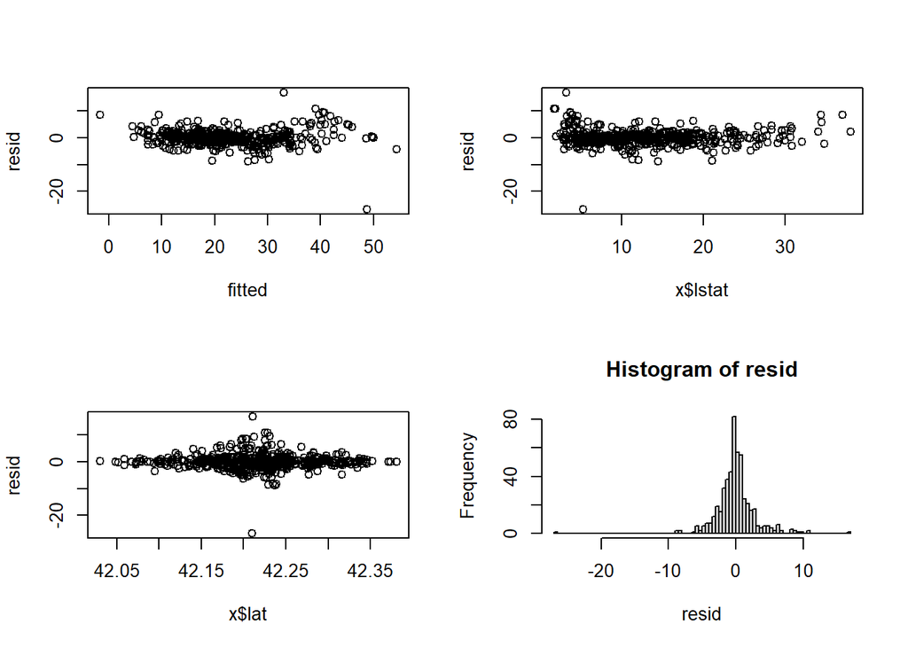

```r
par(mfrow=c(2,2))
plot(fitted,resid)        # Scatter plot fitted vs. residuals
plot(x$lstat,resid)       # Scatter plot lstat vs. residuals
plot(x$lat,resid)         # Scatter lat vs. residuals
hist(resid,100)           # Historgram of residuals with 100 bins
```

```r
par(mfrow=c(1,1))
```

### Predicting with regression

- Split data train and test

```r
idx <- sort(sample(1:nrow(x),100))
xTest <- x[idx,]
xTrain <- x[-idx,]
```

- Fit the model - cmedv ~ lstat + lat

```r
fitTrain <- lm(cmedv ~ lstat + lat, data=xTrain)
fitTrain
```

```
##
## Call:
## lm(formula = cmedv ~ lstat + lat, data = xTrain)
##
## Coefficients:
## (Intercept)        lstat          lat
##   -306.9744      -0.9255       8.0862
```

- Predict with test data.

```r
predict(fitTrain,newdata=xTest)
```

```
##         1         5        10        14        27        30        35        38
## 30.100694 30.124486 19.377208 27.364330 21.262043 23.808359 16.022877 26.847863
##        40        41        44        50        55        66        69        73
## 31.180509 33.435067 28.379552 20.248949 21.954585 31.115352 23.282429 30.005250
##        77        84        86        92        94        97        98       110
## 23.862088 28.260591 29.030090 27.254090 29.293897 24.396619 30.946732 20.310346
##       117       118       138       140       143       144       150       151
## 23.613747 25.233775 21.024947 17.423147  9.623110  9.999769 14.599375 21.406462
##       152       159       170       172       173       183       190       195
## 22.140283 28.512126 24.072272 23.446722 21.005985 30.036102 29.802921 31.044118
##       196       198       203       204       214       217       221       226
## 31.940681 26.882732 31.532140 30.997515 25.870926 21.947640 25.389240 29.959651
##       232       235       242       243       246       249       250       254
## 29.349469 26.929570 22.501871 23.704712 16.871665 25.265889 28.052193 30.767879
##       274       277       278       285       299       303       318       337
## 27.778967 28.368120 30.196511 26.276122 28.634210 25.448500 19.047796 24.612957
##       338       350       357       358       362       378       381       384
## 23.901510 28.247733 18.115551 22.080805 21.213197 14.822027 18.579989 11.753496
##       388       395       406       412       414       417       419       425
##  4.859433 19.127650 13.043508 14.665065 15.693421 10.368532 15.172641 18.318986
##       427       428       431       432       444       447       449       458
## 19.693180 20.795391 17.850500 15.945192 16.732293 17.693889 17.340414 18.344693
##       459       463       469       471       483       485       489       493
## 18.993694 21.070799 17.227206 18.930079 27.506349 21.547020 17.828916 22.271187
##       494       501       504       505
## 23.523452 21.310045 29.255380 28.461809
```

- Predict training data

```r
predict(fitTrain)
```

[output not shown]

[output cut: 81 more lines]

[output not shown]

### Using regression for hypothesis testing

```r
set.seed(1)
x1 <- rnorm(50,mean=20,sd=10)
x2 <- rnorm(50,mean=30,sd=10)
x3 <- rnorm(50,mean=21,sd=10)
```

- Compare x1 and x2

```r
x1x2 <- c(x1,x2)
id12 <- c(rep(1,length(x1)),rep(2,length(x2))) # rep() repeats a number as many times as the 2nd argument instructs.
id12 <- as.factor(id12)
id12
```

```
##   [1] 1 1 1 1 1 1 1 1 1 1 1 1 1 1 1 1 1 1 1 1 1 1 1 1 1 1 1 1 1 1 1 1 1 1 1 1 1
##  [38] 1 1 1 1 1 1 1 1 1 1 1 1 1 2 2 2 2 2 2 2 2 2 2 2 2 2 2 2 2 2 2 2 2 2 2 2 2
##  [75] 2 2 2 2 2 2 2 2 2 2 2 2 2 2 2 2 2 2 2 2 2 2 2 2 2 2
## Levels: 1 2
```

- Build regression model

```r
summary(lm(x1x2~id12))
```

```
##
## Call:
## lm(formula = x1x2 ~ id12)
##
## Residuals:
##      Min       1Q   Median       3Q      Max
## -23.1515  -6.0801   0.0502   5.7503  22.8429
##
## Coefficients:
##             Estimate Std. Error t value Pr(>|t|)
## (Intercept)   21.004      1.277  16.453  < 2e-16 ***
## id122         10.169      1.805   5.632  1.7e-07 ***
## ---
## Signif. codes:  0 '***' 0.001 '**' 0.01 '*' 0.05 '.' 0.1 ' ' 1
##
## Residual standard error: 9.027 on 98 degrees of freedom
## Multiple R-squared:  0.2445, Adjusted R-squared:  0.2368
## F-statistic: 31.72 on 1 and 98 DF,  p-value: 1.702e-07
```

- Compare x1 and x2 mean values

```r
mean(x1)
```

```
## [1] 21.00448
```

```r
mean(x2)-mean(x1)
```

```
## [1] 10.16878
```

- Regression model with x1 and x3

```r
x1x3 <- c(x1,x3)
id13 <- c(rep(1,length(x1)),rep(3,length(x3)))
id13 <- as.factor(id13)
summary(lm(x1x3~id13))
```

```
##
## Call:
## lm(formula = x1x3 ~ id13)
##
## Residuals:
##      Min       1Q   Median       3Q      Max
## -23.1515  -4.9561  -0.5849   5.5163  22.3965
##
## Coefficients:
##             Estimate Std. Error t value Pr(>|t|)
## (Intercept)   21.004      1.225  17.146   <2e-16 ***
## id133         -1.529      1.732  -0.883     0.38
## ---
## Signif. codes:  0 '***' 0.001 '**' 0.01 '*' 0.05 '.' 0.1 ' ' 1
##
## Residual standard error: 8.662 on 98 degrees of freedom
## Multiple R-squared:  0.007889,   Adjusted R-squared:  -0.002235
## F-statistic: 0.7792 on 1 and 98 DF,  p-value: 0.3795
```

- Regression with x1,x2, and x3

```r
x1x2x3 <- c(x1,x2,x3)
id123 <- c(rep(1,length(x1)),rep(2,length(x1)),rep(3,length(x3)))
id123 <- as.factor(id123)
summary(lm(x1x2x3~id123))
```

```
##
## Call:
## lm(formula = x1x2x3 ~ id123)
##
## Residuals:
##      Min       1Q   Median       3Q      Max
## -23.1515  -5.2574  -0.4894   5.3235  22.8429
##
## Coefficients:
##             Estimate Std. Error t value Pr(>|t|)
## (Intercept)   21.004      1.275  16.471  < 2e-16 ***
## id1232        10.169      1.803   5.638 8.52e-08 ***
## id1233        -1.529      1.803  -0.848    0.398
## ---
## Signif. codes:  0 '***' 0.001 '**' 0.01 '*' 0.05 '.' 0.1 ' ' 1
##
## Residual standard error: 9.017 on 147 degrees of freedom
## Multiple R-squared:  0.2528, Adjusted R-squared:  0.2426
## F-statistic: 24.86 on 2 and 147 DF,  p-value: 5.005e-10
```

- Regression model with x1 and x4 ( different sample sizes)

```r
x4 <- rnorm(10,mean=30,sd=10) # Only 10 observations
x1x4 <- c(x1,x4)
id14 <- c(rep(1,length(x1)),rep(2,length(x4))) # I can use any numbers I want, they do not mean anything!
id14 <- as.factor(id14)
summary(lm(x1x4~id14))
```

```
##
## Call:
## lm(formula = x1x4 ~ id14)
##
## Residuals:
##      Min       1Q   Median       3Q      Max
## -23.1515  -5.3123  -0.4623   6.4409  21.2077
##
## Coefficients:
##             Estimate Std. Error t value Pr(>|t|)
## (Intercept)   21.004      1.240  16.943   <2e-16 ***
## id142          6.481      3.037   2.134   0.0371 *
## ---
## Signif. codes:  0 '***' 0.001 '**' 0.01 '*' 0.05 '.' 0.1 ' ' 1
##
## Residual standard error: 8.766 on 58 degrees of freedom
## Multiple R-squared:  0.07281,    Adjusted R-squared:  0.05682
## F-statistic: 4.555 on 1 and 58 DF,  p-value: 0.03707
```

Works just fine! We model the means, so the number of observations will only help with better estimates of the coefficients, but not with the design of the comparison itself.